# Practical Machine Learning Final Project

Rodolfo Leon

2023-05-06

This is Coursera’s Practical Machine Learning course Final Project Report.

## Background

Using devices such as Jawbone Up, Nike FuelBand, and Fitbit it is now possible to collect a large amount of data about personal activity relatively inexpensively. These type of devices are part of the quantified self movement - a group of enthusiasts who take measurements about themselves regularly to improve their health, to find patterns in their behavior, or because they are tech geeks. One thing that people regularly do is quantify how much of a particular activity they do, but they rarely quantify how well they do it. In this project, your goal will be to use data from accelerometers on the belt, forearm, arm, and dumbell of 6 participants. They were asked to perform barbell lifts correctly and incorrectly in 5 different ways. More information is available from the website here: (http://groupware.les.inf.puc-rio.br/har) (see the section on the Weight Lifting Exercise Dataset).

## Objective

The project requires that a prediction be made of the manner in which the experiments subjects performed the exercises. Different models will be tested to select the one with the higher level of accuracy and apply it to the predetermined test data set as well as to the twent y exercises of the final quiz.

## Environment preparation, install required packages

```r
library(tidyverse)
library(ggplot2)
library(lattice)
library(caret)
library(kernlab)
library(rattle)
library(randomForest)
library(corrplot)
library(Amelia)
library(datasets)
library(caTools)
library(party)
library(dplyr)
library(magrittr)
library(xgboost)
```

## Load Data and replace #DIV/0 elements and empty strings witn NA.

```r
train <- read.csv("https://d396qusza40orc.cloudfront.net/predmachlearn/pml-training.csv",
                          na.strings=c('#DIV/0', '', 'NA') ,stringsAsFactors = FALSE)
test <- read.csv("https://d396qusza40orc.cloudfront.net/predmachlearn/pml-testing.csv",
                          na.strings= c('#DIV/0', '', 'NA'),stringsAsFactors = FALSE)
dim(train)
```

```
## [1] 19622   160
```

```r
dim(test)
```

```
## [1]  20 160
```

#### Keep original datasets to preserve data integrity

```r
train1 <- train
test1 <- test
```

#### Check for missing values and zero variance predictors

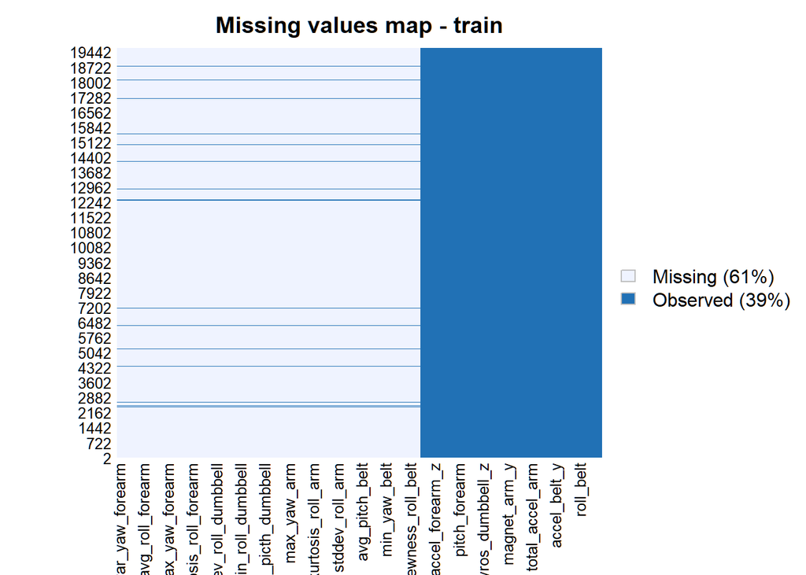

```r
missmap(train, main = "Missing values map - train")
```

There is a substantial number of missing data that must be removed.

#### 1) Remove NA elements

```r
rmNA <- (colSums(is.na(train1)) == 0)
train1 <- train1[, rmNA]
dim(train1)
```

```
## [1] 19622    60
```

#### 2) Remove Near Zero Variables - NZV

```r
nzv <- nearZeroVar(train1)
train1 <- train1[,-nzv]
dim(train1)
```

```
## [1] 19622    59
```

#### 3) Remove columns with variables not relevant to the study

```r
train1 <- train1[,-c(1:7)]
dim(train1)
```

```
## [1] 19622    52
```

## Create and validate the models

Split the clean train1 dataset 70/30 into training and validating datasets. The test1 dataset provided for the exercise will not be used until the end. The model with the highest accuracy will be applied to the final quiz exercises.

```r
inTrain <- createDataPartition(y=train1$classe, p=0.7, list=FALSE)
trainMod <- train1[inTrain,]
validMod <- train1[-inTrain,]
```

We will test several models, namely Decision Trees, Random Forests, Gradient Boosted Trees and Support Vector Machine. We will use a 3-fold cross validation control with the training model.

```r
control <- trainControl(method="cv", number=3, verboseIter=FALSE)
```

### 1. Decision Tree

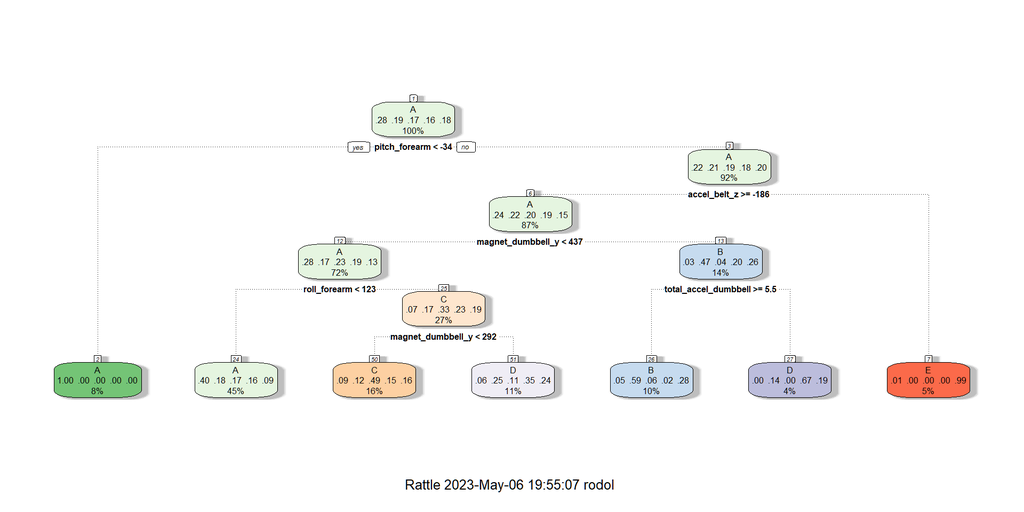

```r
decTree <- train(classe~., data=trainMod, method="rpart", trControl = control, tuneLength = 5)
fancyRpartPlot(decTree$finalModel)
```

```r
treePred <- predict(decTree, validMod)
conf_trees <- confusionMatrix(treePred, factor(validMod$classe))
conf_trees
```

```
## Confusion Matrix and Statistics
##
##           Reference
## Prediction    A    B    C    D    E
##          A 1500  453  499  417  263
##          B   30  349   29   10  157
##          C   94  152  425  148  145
##          D   38  184   73  389  216
##          E   12    1    0    0  301
##
## Overall Statistics
##
##                Accuracy : 0.5037
##                  95% CI : (0.4908, 0.5165)
##     No Information Rate : 0.2845
##     P-Value [Acc > NIR] : < 2.2e-16
##
##                   Kappa : 0.3523
##
##  Mcnemar's Test P-Value : < 2.2e-16
##
## Statistics by Class:
##
##                      Class: A Class: B Class: C Class: D Class: E
## Sensitivity            0.8961  0.30641  0.41423   0.4035  0.27819
## Specificity            0.6124  0.95238  0.88907   0.8962  0.99729
## Pos Pred Value         0.4789  0.60696  0.44087   0.4322  0.95860
## Neg Pred Value         0.9368  0.85122  0.87787   0.8847  0.85981
## Prevalence             0.2845  0.19354  0.17434   0.1638  0.18386
## Detection Rate         0.2549  0.05930  0.07222   0.0661  0.05115
## Detection Prevalence   0.5322  0.09771  0.16381   0.1529  0.05336
## Balanced Accuracy      0.7543  0.62940  0.65165   0.6498  0.63774
```

### 2. Random Forest

```r
rfMod <- train(classe~., data=trainMod, method="rf", trControl = control, tuneLength = 5)
rfPred <- predict(rfMod, validMod)
rfConf <- confusionMatrix(rfPred, factor(validMod$classe))
rfConf
```

```
## Confusion Matrix and Statistics
##
##           Reference
## Prediction    A    B    C    D    E
##          A 1674    7    0    0    0
##          B    0 1129    3    0    0
##          C    0    3 1021   11    2
##          D    0    0    2  952    3
##          E    0    0    0    1 1077
##
## Overall Statistics
##
##                Accuracy : 0.9946
##                  95% CI : (0.9923, 0.9963)
##     No Information Rate : 0.2845
##     P-Value [Acc > NIR] : < 2.2e-16
##
##                   Kappa : 0.9931
##
##  Mcnemar's Test P-Value : NA
##
## Statistics by Class:
##
##                      Class: A Class: B Class: C Class: D Class: E
## Sensitivity            1.0000   0.9912   0.9951   0.9876   0.9954
## Specificity            0.9983   0.9994   0.9967   0.9990   0.9998
## Pos Pred Value         0.9958   0.9973   0.9846   0.9948   0.9991
## Neg Pred Value         1.0000   0.9979   0.9990   0.9976   0.9990
## Prevalence             0.2845   0.1935   0.1743   0.1638   0.1839
## Detection Rate         0.2845   0.1918   0.1735   0.1618   0.1830
## Detection Prevalence   0.2856   0.1924   0.1762   0.1626   0.1832
## Balanced Accuracy      0.9992   0.9953   0.9959   0.9933   0.9976
```

### 3. Gradient Boosted Trees - GBM

```r
gbmMod <- train(classe~., data=trainMod, method="gbm", trControl = control, tuneLength = 5, verbose = FALSE)
gbmPred <- predict(gbmMod, validMod)
gbmConf <- confusionMatrix(gbmPred, factor(validMod$classe))
gbmConf
```

```
## Confusion Matrix and Statistics
##
##           Reference
## Prediction    A    B    C    D    E
##          A 1673    8    0    0    0
##          B    0 1123    9    0    2
##          C    1    7 1008   10    2
##          D    0    0    8  953    5
##          E    0    1    1    1 1073
##
## Overall Statistics
##
##                Accuracy : 0.9907
##                  95% CI : (0.9879, 0.993)
##     No Information Rate : 0.2845
##     P-Value [Acc > NIR] : < 2.2e-16
##
##                   Kappa : 0.9882
##
##  Mcnemar's Test P-Value : NA
##
## Statistics by Class:
##
##                      Class: A Class: B Class: C Class: D Class: E
## Sensitivity            0.9994   0.9860   0.9825   0.9886   0.9917
## Specificity            0.9981   0.9977   0.9959   0.9974   0.9994
## Pos Pred Value         0.9952   0.9903   0.9805   0.9865   0.9972
## Neg Pred Value         0.9998   0.9966   0.9963   0.9978   0.9981
## Prevalence             0.2845   0.1935   0.1743   0.1638   0.1839
## Detection Rate         0.2843   0.1908   0.1713   0.1619   0.1823
## Detection Prevalence   0.2856   0.1927   0.1747   0.1641   0.1828
## Balanced Accuracy      0.9988   0.9918   0.9892   0.9930   0.9955
```

### 4. Support Vector Machine - SVM

```r
svmMod <- train(classe~., data=trainMod, method="svmLinear", trControl = control, tuneLength = 5, verbose = FALSE)
svmPred <- predict(svmMod, validMod)
svmConf <- confusionMatrix(svmPred, factor(validMod$classe))
svmConf
```

```
## Confusion Matrix and Statistics
##
##           Reference
## Prediction    A    B    C    D    E
##          A 1563  147   90   63   77
##          B   27  805   84   32  129
##          C   41   80  777  118   53
##          D   37   20   54  700   72
##          E    6   87   21   51  751
##
## Overall Statistics
##
##                Accuracy : 0.781
##                  95% CI : (0.7702, 0.7915)
##     No Information Rate : 0.2845
##     P-Value [Acc > NIR] : < 2.2e-16
##
##                   Kappa : 0.7213
##
##  Mcnemar's Test P-Value : < 2.2e-16
##
## Statistics by Class:
##
##                      Class: A Class: B Class: C Class: D Class: E
## Sensitivity            0.9337   0.7068   0.7573   0.7261   0.6941
## Specificity            0.9105   0.9427   0.9399   0.9628   0.9656
## Pos Pred Value         0.8057   0.7474   0.7268   0.7928   0.8199
## Neg Pred Value         0.9719   0.9305   0.9483   0.9472   0.9334
## Prevalence             0.2845   0.1935   0.1743   0.1638   0.1839
## Detection Rate         0.2656   0.1368   0.1320   0.1189   0.1276
## Detection Prevalence   0.3297   0.1830   0.1816   0.1500   0.1556
## Balanced Accuracy      0.9221   0.8247   0.8486   0.8445   0.8299
```

### Accuracy Results

[output not shown]

## Prediction on test set

```r
rfPred <- predict(rfMod, test)
rfPred
```

```
##  [1] B A B A A E D B A A B C B A E E A B B B
## Levels: A B C D E
```

Plot the Models

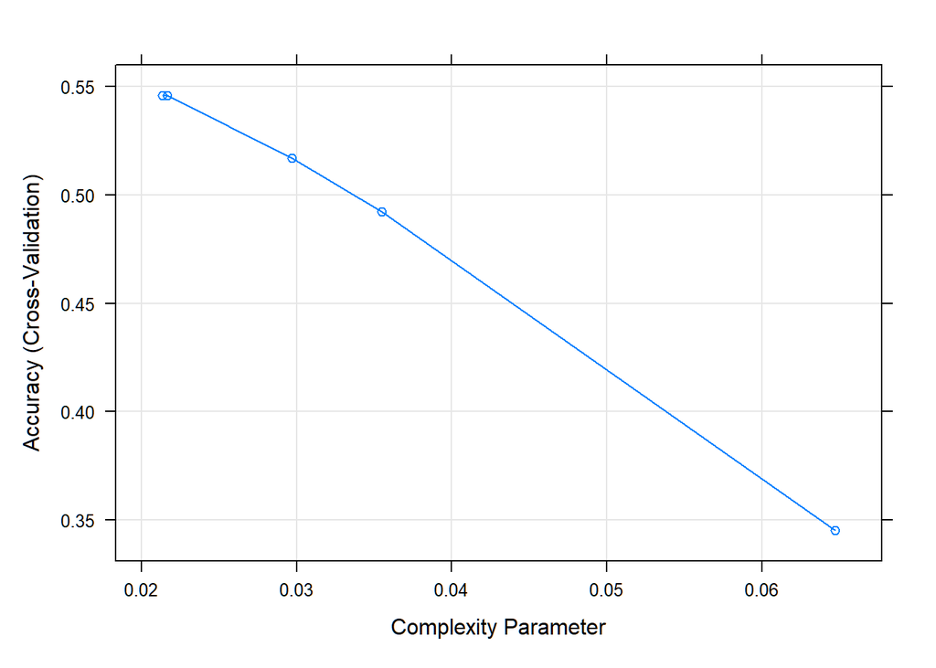

```r
plot(decTree)
```

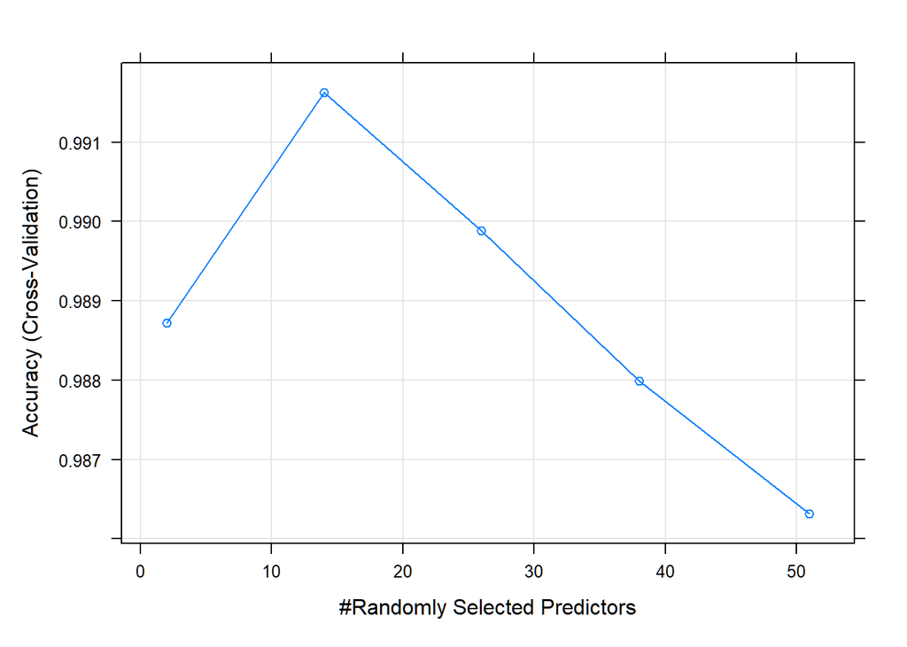

```r
plot(rfMod)
```

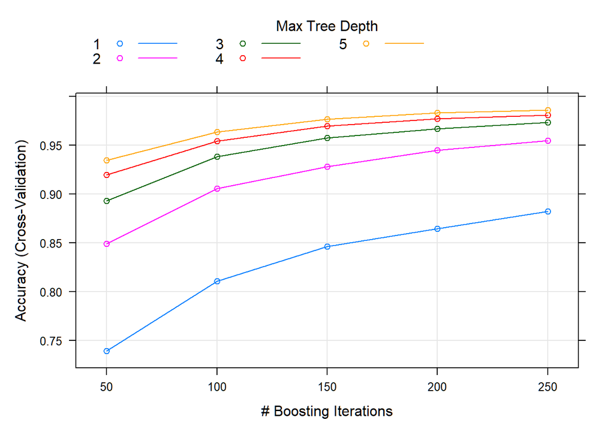

```r
plot(gbmMod)
```